# 机器学习选股模型 — 季度 Top 30 策略

**目标**：用 A 股财务因子（估值 + 成长共 19 个）训练机器学习模型，预测股票下季度收益率 `Next_Ret`，每个季度选取预测得分最高的 30 只构建组合，对比 **等权** 与 **预测值加权** 两种配置方式的效果。

**流程**：数据加载 → 预处理（去极值 + 标准化 + 时间切分 + 双标签）→ 四模型训练 → Top 30 选股 → 等权 vs 加权对比 → 策略评估（净值曲线 / 指标表 / 分组检验 / IC）。

> 数据：`model_data.csv`（39,616 行 × 22 列，10 个季度 2020Q1–2022Q2） 训练集：2020Q1–2021Q2（6 季）｜ 测试集：2021Q3–2022Q2（4 季）

```python
import os, pickle, warnings
import numpy as np
import pandas as pd
import matplotlib.pyplot as plt
import seaborn as sns
from scipy.stats import spearmanr
from sklearn.linear_model import LinearRegression, LogisticRegression
from sklearn.tree import DecisionTreeRegressor
from sklearn.ensemble import RandomForestRegressor
from sklearn.preprocessing import StandardScaler
from sklearn.impute import SimpleImputer
from sklearn.metrics import r2_score, roc_auc_score

%matplotlib inline
warnings.filterwarnings('ignore')
pd.set_option('display.max_columns', None)
pd.set_option('display.float_format', lambda x: f'{x:.4f}')

plt.rcParams['figure.dpi'] = 100
plt.rcParams['font.size'] = 12
sns.set_theme(style='whitegrid')
# 中文字体：必须在 sns.set_theme 之后设置，否则会被重置
plt.rcParams['font.sans-serif'] = ['PingFang SC','Heiti SC','Hiragino Sans GB','Arial Unicode MS','SimHei','Microsoft YaHei']
plt.rcParams['axes.unicode_minus'] = False

os.makedirs('models', exist_ok=True)
os.makedirs('results', exist_ok=True)
model_test_scores = {}   # 模型名 -> 测试集(含预测得分 score)
print('环境就绪，中文字体已设置')
```

```
环境就绪，中文字体已设置
```

## 3. 数据加载与探索（EDA）

先看数据规模、季度分布、目标变量 `Next_Ret` 的分布，以及各因子与收益率的相关性。

```python
raw = pd.read_csv('model_data.csv')
raw['Date'] = pd.to_datetime(raw['Date'])
raw['Quarter'] = raw['Date'].dt.to_period('Q').astype(str)

feature_cols = [c for c in raw.columns if c not in ['Date','Code','Next_Ret','Quarter']]
print('数据形状 :', raw.shape)
print('季度列表 :', sorted(raw['Quarter'].unique()))
print('股票数量 :', raw['Code'].nunique())
print('特征数量 :', len(feature_cols))
print('标签缺失 :', raw['Next_Ret'].isna().sum())
```

```
数据形状 : (39616, 23)
季度列表 : ['2020Q1', '2020Q2', '2020Q3', '2020Q4', '2021Q1', '2021Q2', '2021Q3', '2021Q4', '2022Q1', '2022Q2']
股票数量 : 4281
特征数量 : 19
标签缺失 : 0
```

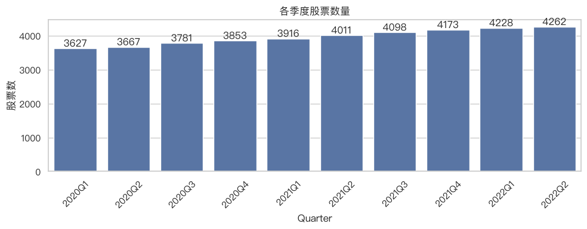

```python
# 各季度股票数量
qcount = raw.groupby('Quarter')['Code'].count()
fig, ax = plt.subplots(figsize=(10,4))
sns.barplot(x=qcount.index, y=qcount.values, color='#4C72B0', ax=ax)
ax.set_title('各季度股票数量')
ax.set_ylabel('股票数')
for i,v in enumerate(qcount.values): ax.text(i, v+50, str(v), ha='center')
plt.xticks(rotation=45); plt.tight_layout(); plt.show()
```

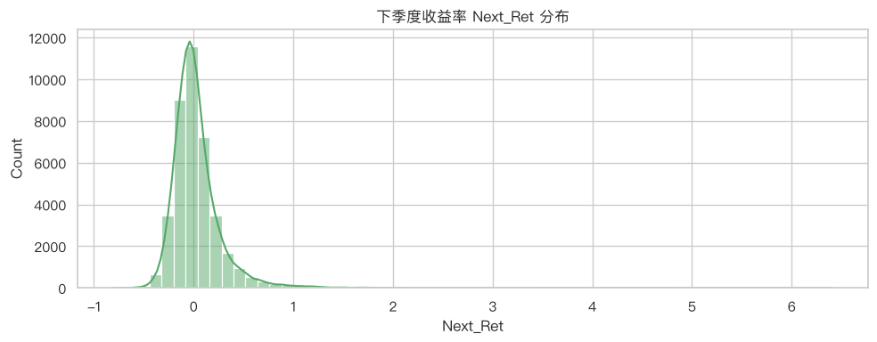

```
Next_Ret 描述统计:
count   39616.0000
mean        0.0270
std         0.2514
min        -0.7999
25%        -0.1162
50%        -0.0138
75%         0.1116
max         6.4066
Name: Next_Ret, dtype: float64
```

```python
# 目标变量分布
fig, ax = plt.subplots(figsize=(10,4))
sns.histplot(raw['Next_Ret'], bins=60, kde=True, color='#55A868', ax=ax)
ax.set_title('下季度收益率 Next_Ret 分布')
ax.set_xlabel('Next_Ret')
plt.tight_layout(); plt.show()
print('Next_Ret 描述统计:')
print(raw['Next_Ret'].describe().round(4))
```

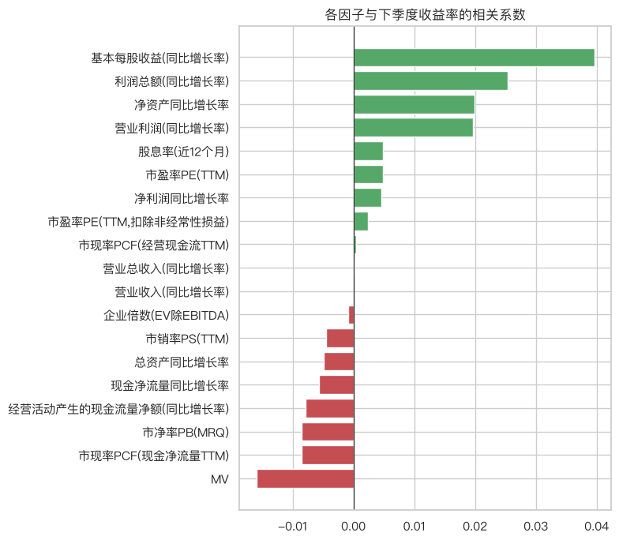

```python
# 各因子与 Next_Ret 的相关系数（全样本）
corr = raw[feature_cols + ['Next_Ret']].corr()['Next_Ret'].drop('Next_Ret').sort_values()
fig, ax = plt.subplots(figsize=(8,7))
colors = ['#C44E52' if v < 0 else '#55A868' for v in corr.values]
ax.barh(corr.index, corr.values, color=colors)
ax.axvline(0, color='k', lw=0.8)
ax.set_title('各因子与下季度收益率的相关系数')
plt.tight_layout(); plt.show()
```

## 4. 数据预处理与特征工程

1. **缺失值**：中位数填充
2. **去极值（MAD）**：用训练集的中位数 ± 5×MAD 截断极端值，避免个别异常值压垮模型
3. **标准化**：`StandardScaler` 仅用训练集 fit，再 transform 测试集（防数据泄露）
4. **时间切分**：严格按季度，训练集在前、测试集在后
5. **双标签**：
   - 回归标签：`Next_Ret` 原值（线性回归 / 决策树 / 随机森林）
   - 分类标签：季度内 `Next_Ret` 排名前 30% → 1，否则 0（逻辑回归，用预测概率排序选股）

```python
train_quarters = ['2020Q1','2020Q2','2020Q3','2020Q4','2021Q1','2021Q2']
test_quarters  = ['2021Q3','2021Q4','2022Q1','2022Q2']
train_mask = raw['Quarter'].isin(train_quarters)
test_mask  = raw['Quarter'].isin(test_quarters)

# 1) 缺失值填充
imputer = SimpleImputer(strategy='median')
X_imputed = pd.DataFrame(
    imputer.fit_transform(raw[feature_cols]),
    columns=feature_cols, index=raw.index)

# 2) MAD 去极值（用训练集估计参数，应用到全量）
mad_params = {}
for c in feature_cols:
    med = X_imputed.loc[train_mask, c].median()
    mad = (X_imputed.loc[train_mask, c] - med).abs().median()
    mad_params[c] = (med, mad)
def clip_mad(df):
    df = df.copy()
    for c in feature_cols:
        med, mad = mad_params[c]
        df[c] = df[c].clip(med - 5*mad, med + 5*mad)
    return df
X_clip = clip_mad(X_imputed)

# 3) 标准化
scaler = StandardScaler()
X_train = pd.DataFrame(scaler.fit_transform(X_clip.loc[train_mask]), columns=feature_cols)
X_test  = pd.DataFrame(scaler.transform(X_clip.loc[test_mask]),  columns=feature_cols)

# 4) 标签
y_train_reg = raw.loc[train_mask, 'Next_Ret'].values
y_test_reg  = raw.loc[test_mask,  'Next_Ret'].values
def make_cls(df):
    return df.groupby('Quarter')['Next_Ret'].transform(lambda s: (s >= s.quantile(0.7)).astype(int))
y_train_cls = make_cls(raw.loc[train_mask]).values
y_test_cls  = make_cls(raw.loc[test_mask]).values

# 测试集基础表（选股用）
test_df = raw.loc[test_mask, ['Date','Quarter','Code','Next_Ret']].reset_index(drop=True)

print('训练样本数:', len(X_train), '| 测试样本数:', len(X_test))
print('训练正类占比(Top30%):', round(y_train_cls.mean(),3), '| 测试:', round(y_test_cls.mean(),3))
```

```
训练样本数: 22855 | 测试样本数: 16761
训练正类占比(Top30%): 0.3 | 测试: 0.3
```

## 5. 线性回归（Baseline）

用线性模型直接回归预测 `Next_Ret`，作为最朴素的基线。

```python
lin = LinearRegression()
lin.fit(X_train, y_train_reg)
y_pred_tr = lin.predict(X_train)
y_pred_te = lin.predict(X_test)
print('线性回归  训练R2:', round(r2_score(y_train_reg, y_pred_tr),4),
      '| 测试R2:', round(r2_score(y_test_reg, y_pred_te),4))
with open('models/linear_regression.pkl','wb') as f: pickle.dump(lin, f)
ts = test_df.copy(); ts['score'] = y_pred_te
model_test_scores['线性回归'] = ts
print('已保存 models/linear_regression.pkl')
```

```
线性回归  训练R2: 0.0273 | 测试R2: -0.0676
已保存 models/linear_regression.pkl
```

## 6. 逻辑回归（分类版：Top 30% 标签）

把"季度内收益率排名前 30%"作为正类，训练逻辑回归，用正类预测概率作为选股排序分数——这样模型学的就是"能否进入 Top 30"，与选股目标天然对齐。

```python
logit = LogisticRegression(max_iter=1000)
logit.fit(X_train, y_train_cls)
p_tr = logit.predict_proba(X_train)[:,1]
p_te = logit.predict_proba(X_test)[:,1]
print('逻辑回归  训练AUC:', round(roc_auc_score(y_train_cls, p_tr),4),
      '| 测试AUC:', round(roc_auc_score(y_test_cls, p_te),4))
with open('models/logistic_regression.pkl','wb') as f: pickle.dump(logit, f)
ts = test_df.copy(); ts['score'] = p_te
model_test_scores['逻辑回归'] = ts
print('已保存 models/logistic_regression.pkl')
```

```
逻辑回归  训练AUC: 0.6033 | 测试AUC: 0.5426
已保存 models/logistic_regression.pkl
```

## 7. 决策树（回归）

限制 `max_depth=5` 防止过拟合。

```
决策树  训练R2: 0.0571 | 测试R2: -0.0822
```

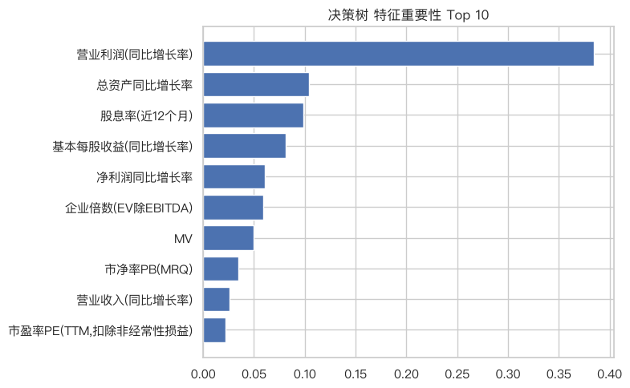

```
已保存 models/decision_tree.pkl
```

```python
dt = DecisionTreeRegressor(max_depth=5, random_state=42)
dt.fit(X_train, y_train_reg)
y_pred_te = dt.predict(X_test)
print('决策树  训练R2:', round(r2_score(y_train_reg, dt.predict(X_train)),4),
      '| 测试R2:', round(r2_score(y_test_reg, y_pred_te),4))
imp = pd.Series(dt.feature_importances_, index=feature_cols).sort_values(ascending=False).head(10)
plt.figure(figsize=(8,5))
plt.barh(imp.index, imp.values, color='#4C72B0')
plt.title('决策树 特征重要性 Top 10'); plt.gca().invert_yaxis()
plt.tight_layout(); plt.show()
with open('models/decision_tree.pkl','wb') as f: pickle.dump(dt, f)
ts = test_df.copy(); ts['score'] = y_pred_te
model_test_scores['决策树'] = ts
print('已保存 models/decision_tree.pkl')
```

## 8. 随机森林（回归）

`n_estimators=200`，通过多棵树投票提升稳定性。

```
随机森林  训练R2: 0.2045 | 测试R2: -0.0549
```

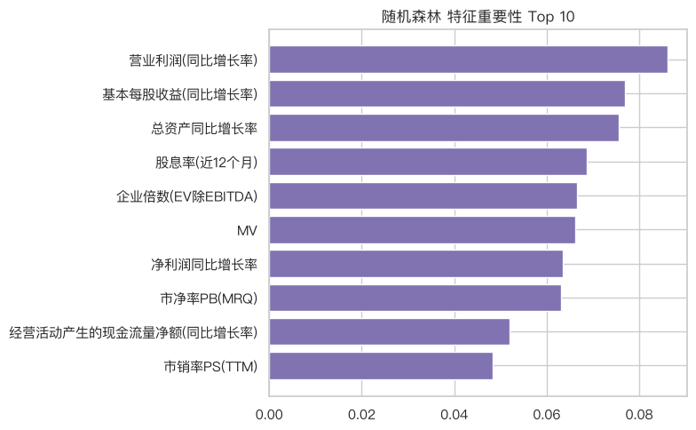

```
已保存 models/random_forest.pkl
```

```python
rf = RandomForestRegressor(n_estimators=200, max_depth=8, random_state=42, n_jobs=-1)
rf.fit(X_train, y_train_reg)
y_pred_te = rf.predict(X_test)
print('随机森林  训练R2:', round(r2_score(y_train_reg, rf.predict(X_train)),4),
      '| 测试R2:', round(r2_score(y_test_reg, y_pred_te),4))
imp = pd.Series(rf.feature_importances_, index=feature_cols).sort_values(ascending=False).head(10)
plt.figure(figsize=(8,5))
plt.barh(imp.index, imp.values, color='#8172B2')
plt.title('随机森林 特征重要性 Top 10'); plt.gca().invert_yaxis()
plt.tight_layout(); plt.show()
with open('models/random_forest.pkl','wb') as f: pickle.dump(rf, f)
ts = test_df.copy(); ts['score'] = y_pred_te
model_test_scores['随机森林'] = ts
print('已保存 models/random_forest.pkl')
```

## 9. Top 30 选股策略构建

对测试集**每个季度**：按模型预测得分降序排序，取前 30 只，分别构建两种组合：

- **等权组合**：每只权重 = 1/30
- **预测值加权组合**：权重 = 预测得分（负值置 0）归一化，得分高的多配

并构建"等权全市场"基准作对比。

```python
def build_portfolio(ts, top_n=30):
    rows = []
    for q in sorted(ts['Quarter'].unique()):
        sub = ts[ts['Quarter']==q].copy().sort_values('score', ascending=False).head(top_n)
        eq = sub['Next_Ret'].mean()
        w = sub['score'].clip(lower=0)
        w = w / w.sum() if w.sum() > 0 else pd.Series(1/len(sub), index=sub.index)
        pw = (w * sub['Next_Ret']).sum()
        rows.append({'Quarter': q, 'equal_ret': eq, 'pred_ret': pw, 'n': len(sub)})
    return pd.DataFrame(rows)

portfolios = {}
for name, ts in model_test_scores.items():
    pf = build_portfolio(ts)
    pf['cum_equal'] = (1 + pf['equal_ret']).cumprod() - 1
    pf['cum_pred']  = (1 + pf['pred_ret']).cumprod() - 1
    portfolios[name] = pf
    print(f"{name:6s} | 等权累计 {pf['cum_equal'].iloc[-1]:+.3f} | 预测加权累计 {pf['cum_pred'].iloc[-1]:+.3f}")

bench = test_df.groupby('Quarter')['Next_Ret'].mean().rename('bench_ret').reset_index()
bench['cum_bench'] = (1 + bench['bench_ret']).cumprod() - 1
print('基准    | 等权全市场累计', f"{bench['cum_bench'].iloc[-1]:+.3f}")
```

```
线性回归   | 等权累计 +0.190 | 预测加权累计 +0.192
逻辑回归   | 等权累计 -0.006 | 预测加权累计 -0.007
决策树    | 等权累计 +0.104 | 预测加权累计 +0.016
随机森林   | 等权累计 +0.142 | 预测加权累计 +0.156
基准    | 等权全市场累计 -0.064
```

## 10. 策略评估与可视化

对比四种模型 × 两种加权方式的净值曲线，计算累计收益、年化、波动、夏普、最大回撤、胜率，并做分组检验与 IC 分析。

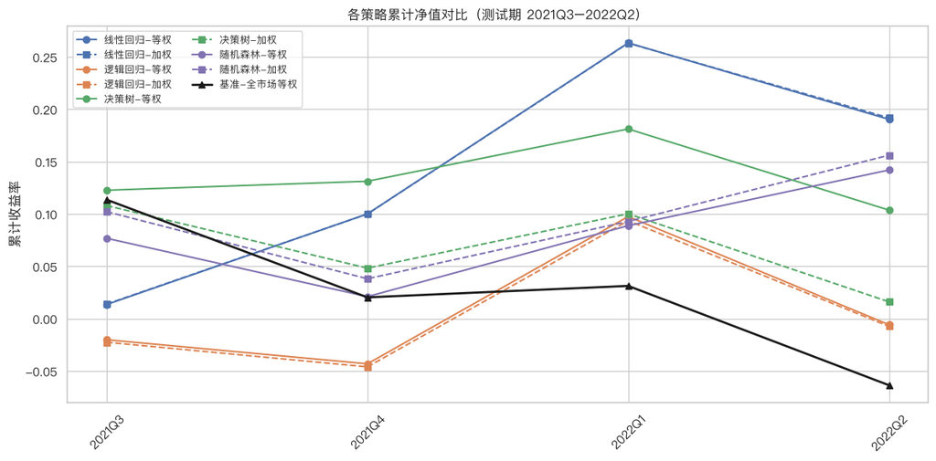

```python
palette = {'线性回归':'#4C72B0','逻辑回归':'#DD8452','决策树':'#55A868','随机森林':'#8172B2'}
fig, ax = plt.subplots(figsize=(12,6))
for name, pf in portfolios.items():
    ax.plot(pf['Quarter'], pf['cum_equal'], marker='o', ls='-',  color=palette[name], label=f'{name}-等权')
    ax.plot(pf['Quarter'], pf['cum_pred'],  marker='s', ls='--', color=palette[name], label=f'{name}-加权')
ax.plot(bench['Quarter'], bench['cum_bench'], marker='^', color='k', lw=2, label='基准-全市场等权')
ax.set_title('各策略累计净值对比（测试期 2021Q3–2022Q2）')
ax.set_ylabel('累计收益率'); ax.legend(fontsize=9, ncol=2)
plt.xticks(rotation=45); plt.tight_layout(); plt.show()
```

```python
def metrics(ret, bench_ret):
    cum = (1 + ret).cumprod() - 1
    total = cum.iloc[-1]
    ann = (1 + total) ** (4/len(ret)) - 1
    vol = ret.std() * np.sqrt(4)
    sharpe = (ann - 0.02) / vol if vol > 0 else np.nan
    nav = (1 + ret).cumprod()
    mdd = (nav / nav.cummax() - 1).min()
    win = (ret > bench_ret).mean()
    return dict(累计收益=total, 年化收益=ann, 年化波动=vol, 夏普=sharpe, 最大回撤=mdd, 胜率=win)

rows = []
for name, pf in portfolios.items():
    me = metrics(pf['equal_ret'], bench['bench_ret']); me.update({'模型':name,'加权方式':'等权'}); rows.append(me)
    mp = metrics(pf['pred_ret'],  bench['bench_ret']); mp.update({'模型':name,'加权方式':'预测加权'}); rows.append(mp)
mb = metrics(bench['bench_ret'], bench['bench_ret']); mb.update({'模型':'基准','加权方式':'全市场等权'}); rows.append(mb)
metric_df = pd.DataFrame(rows)[['模型','加权方式','累计收益','年化收益','年化波动','夏普','最大回撤','胜率']].round(4)
print('===== 策略评估指标 =====')
display(metric_df)
```

```
===== 策略评估指标 =====
```

|  | 模型 | 加权方式 | 累计收益 | 年化收益 | 年化波动 | 夏普 | 最大回撤 | 胜率 |
| --- | --- | --- | --- | --- | --- | --- | --- | --- |
| 0 | 线性回归 | 等权 | 0.1904 | 0.1904 | 0.1784 | 0.9552 | -0.0578 | 0.7500 |
| 1 | 线性回归 | 预测加权 | 0.1918 | 0.1918 | 0.1771 | 0.9699 | -0.0565 | 0.7500 |
| 2 | 逻辑回归 | 等权 | -0.0057 | -0.0057 | 0.2046 | -0.1257 | -0.0941 | 0.5000 |
| 3 | 逻辑回归 | 预测加权 | -0.0073 | -0.0073 | 0.2033 | -0.1344 | -0.0923 | 0.5000 |
| 4 | 决策树 | 等权 | 0.1037 | 0.1037 | 0.1566 | 0.5345 | -0.0656 | 1.0000 |
| 5 | 决策树 | 预测加权 | 0.0161 | 0.0161 | 0.1740 | -0.0224 | -0.0830 | 0.7500 |
| 6 | 随机森林 | 等权 | 0.1420 | 0.1420 | 0.1180 | 1.0335 | -0.0518 | 0.7500 |
| 7 | 随机森林 | 预测加权 | 0.1561 | 0.1561 | 0.1365 | 0.9971 | -0.0581 | 0.7500 |
| 8 | 基准 | 全市场等权 | -0.0635 | -0.0635 | 0.1927 | -0.4336 | -0.1591 | 0.0000 |

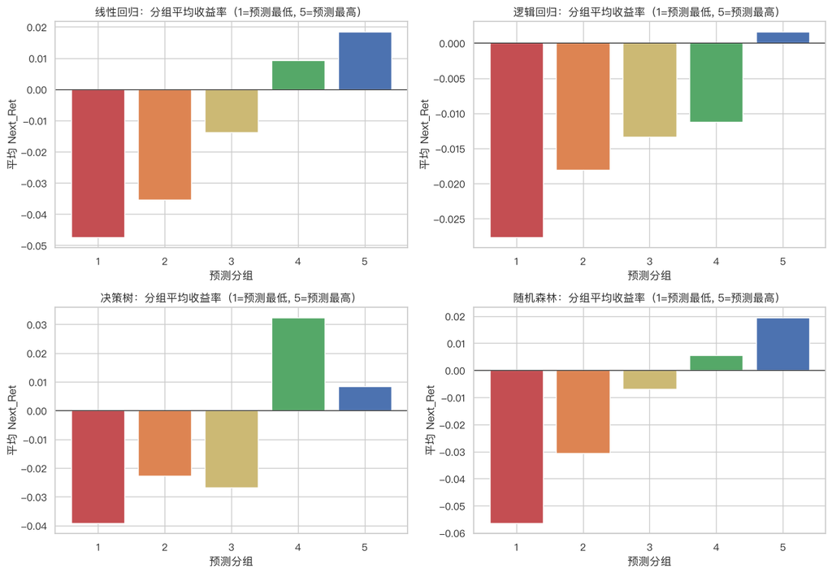

```python
# 分组检验：每模型每季度按预测得分分 5 组，看高分组是否跑赢低分组
fig, axes = plt.subplots(2,2, figsize=(13,9))
bar_colors = ['#C44E52','#DD8452','#CCB974','#55A868','#4C72B0']
for ax,(name,ts) in zip(axes.ravel(), model_test_scores.items()):
    t = ts.copy()
    t['group'] = t.groupby('Quarter')['score'].transform(lambda s: pd.qcut(s, 5, labels=False) + 1)
    g = t.groupby('group')['Next_Ret'].mean()
    ax.bar(g.index.astype(str), g.values, color=bar_colors[:len(g)])
    ax.axhline(0, color='k', lw=0.8)
    ax.set_title(f'{name}：分组平均收益率（1=预测最低, 5=预测最高）')
    ax.set_xlabel('预测分组'); ax.set_ylabel('平均 Next_Ret')
plt.tight_layout(); plt.show()
```

```python
# IC 分析：每季度预测分与实际收益的 Spearman 相关
ic_rows = []
for name, ts in model_test_scores.items():
    ic_list = []
    for q in sorted(ts['Quarter'].unique()):
        d = ts[ts['Quarter']==q]
        ic_list.append(d['score'].corr(d['Next_Ret'], method='spearman'))
    ic = pd.Series(ic_list, index=sorted(ts['Quarter'].unique()))
    ic_rows.append({'模型':name, '平均IC':ic.mean(), 'IC_IR':ic.mean()/ic.std()})
ic_df = pd.DataFrame(ic_rows).round(4)
print('===== IC 分析 =====')
display(ic_df)
```

```
===== IC 分析 =====
```

|  | 模型 | 平均IC | IC_IR |
| --- | --- | --- | --- |
| 0 | 线性回归 | 0.1541 | 1.1281 |
| 1 | 逻辑回归 | 0.0520 | 0.2871 |
| 2 | 决策树 | 0.1323 | 1.0909 |
| 3 | 随机森林 | 0.1640 | 1.2441 |

```python
# 保存结果
metric_df.to_csv('results/strategy_metrics.csv', index=False, encoding='utf-8-sig')
cum_summary = pd.DataFrame({'Quarter': bench['Quarter']})
for name, pf in portfolios.items():
    cum_summary[f'{name}_等权'] = pf['cum_equal'].values
    cum_summary[f'{name}_加权'] = pf['cum_pred'].values
cum_summary['基准'] = bench['cum_bench'].values
cum_summary.to_csv('results/cumulative_returns.csv', index=False, encoding='utf-8-sig')
print('结果已保存到 results/')
```

```
结果已保存到 results/
```

> 注：本作业为示例教学用途，回测期仅 4 个季度，结论不构成投资建议。